# validating SBI

We'll implement different SBI validation techniques such as simulation-based calibration, probability-probability plots, and TARP

```python
import numpy as np
import matplotlib.pyplot as plt
import corner
```

```python
import torch
import sbi
from sbi.inference import NPE
```

```python
np.random.seed(1)
```

# Example 1

Let's go straight into the example of fitting a line to some data. This is the same example as previous notebooks.

```python
a_true, b_true = 0, 1.75
x = np.array([1, 1.5, 2, 2.5])
y = np.array([1.87640523, 2.59001572, 3.4978738 , 4.47408932])
yerr = 0.1
```

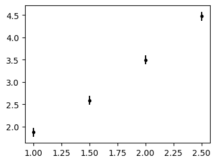

```python
plt.figure(figsize=(4,3))
plt.errorbar(x, y, yerr=yerr, fmt='.k'); plt.show()
```

```python
def simulation(theta):
    a, b = theta
    noise = yerr * np.random.normal(size=len(x))
    return a + b * x + noise

def sample_prior():
    # sample a and b from uniform prior
    _a = -0.5 + np.random.normal()
    _b = 5 + 3*np.random.normal()
    return [_a, _b]
```

draw $(\theta', \mathcal{D}') \sim p(\theta, \mathcal{D})$ samples to train neural posterior estimator

```python
Nsample = 500000

samples = np.zeros((Nsample, 6))
for i in range(Nsample):
    theta_p = sample_prior()
    data_p = simulation(theta_p)
    samples[i,:] = np.concatenate([theta_p, data_p])
samples = torch.tensor(samples, dtype=torch.float32)
```

train a neural posterior estimator using MAF

```python
maf = NPE(density_estimator='maf')

# append (theta, D) from the simulations
_ = maf.append_simulations(samples[:,:2], samples[:,2:])
# train NPE.
npe_maf = maf.train()
```

```
 Neural network successfully converged after 57 epochs.
```

```python
npe_maf = maf.build_posterior()
q_samples = npe_maf.sample((10000,), x=torch.tensor(y, dtype=torch.float32))
```

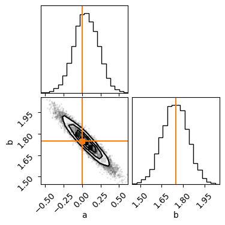

```python
fig = plt.figure(figsize=(4,4))
fig = corner.corner(q_samples.numpy(), labels=['a', 'b'], fig=fig)
corner.overplot_lines(fig, [a_true, b_true], color="C1")
corner.overplot_points(fig, np.array([a_true, b_true])[None], marker="s", color="C1")
```

This looks like a reasonable posterior but we need to validate it more rigorously.

# posterior predictive test

One common validation step is the posterior predictive check

$$\theta' \sim q_\phi(\theta|\mathcal{D}_{\rm obs})$$ then compare $F(\theta')$ to $\mathcal{D}_{\rm obs}$

```python
y_p = []
for theta_p in q_samples.numpy():
    y_p.append(simulation(theta_p))
y_p = np.array(y_p)
```

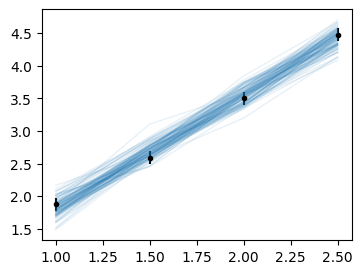

```python
plt.figure(figsize=(4,3))
plt.errorbar(x, y, yerr=yerr, fmt='.k')
for _y in y_p[::100]:
    plt.plot(x, _y, c='C0', lw=1, alpha=0.1)
```

Looks consistent but we want a more statistically rigorous validation using coverage tests

# construct test simulations

Draw $(\theta', \mathcal{D}') \sim p(\theta, \mathcal{D})$ using the same prior and simulator

```python
Ntest = 1000

theta_test = np.zeros((Ntest, 2))
data_test = np.zeros((Ntest, 4))
for i in range(Ntest):
    theta_p = sample_prior()
    data_p = simulation(theta_p)

    theta_test[i,:] = theta_p
    data_test[i,:] = data_p
```

# simulation-based calibration (SBC)

Let's start with SBC

The algorithm is simple:

```
for theta_test, data_test in test_samples:

    # draw samples from posterior estimate
    q_samples = NPE(data_test)

    # compute rank
    rank = sum(q_samples < theta_test)
```

```python
ranks_a = []
ranks_b = []

for _theta, _data in zip(theta_test, data_test):
    _q_samples = npe_maf.sample((2000,),
                                x=torch.tensor(_data, dtype=torch.float32),
                                show_progress_bars=False)

    # calculate rank for each dimension
    ranks_a.append(np.sum(_q_samples.numpy()[:,0] < _theta[0]))
    ranks_b.append(np.sum(_q_samples.numpy()[:,1] < _theta[1]))
```

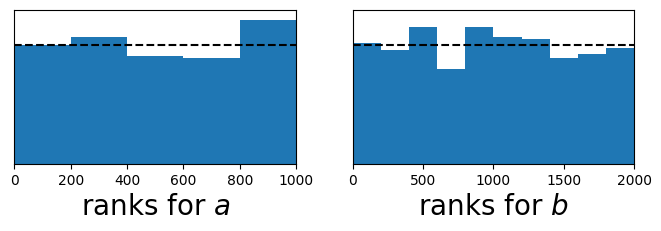

```python
fig = plt.figure(figsize=(8,2))
sub = fig.add_subplot(121)
_ = sub.hist(ranks_a, range=(0, 2000), bins=10)
sub.axhline(Ntest/10, color='k', linestyle='--')
sub.set_xlabel('ranks for $a$', fontsize=20)
sub.set_yticks([]); sub.set_xlim(0, 1000); sub.set_ylim(0., 1.3*Ntest/10)

sub = fig.add_subplot(122)
sub.hist(ranks_b, range=(0, 2000), bins=10)
sub.axhline(Ntest/10, color='k', linestyle='--')
sub.set_xlabel('ranks for $b$', fontsize=20)
sub.set_yticks([]); sub.set_xlim(0, 2000); sub.set_ylim(0., 1.3*Ntest/10)
plt.show()
```

SBC shows that $q_\phi$ is relatively well calibrated.

## probability-probability plot

For the PP plot, we only need to modify the rank statistic to estimate coverage

```
for theta_test, data_test in test_samples:
    # drawn samples from posterior estimate
    q_samples = NPE(data_test)

    # estimate coverage
    coverage = quantile(q_samples, theta_test)
```

```python
hist_a, _ = np.histogram(np.array(ranks_a) / 2000,
                         range=(0., 1.), bins=100)
cdf_a = np.cumsum(hist_a) / Ntest

hist_b, _ = np.histogram(np.array(ranks_b) / 2000,
                         range=(0., 1.), bins=100)
cdf_b = np.cumsum(hist_b) / Ntest
```

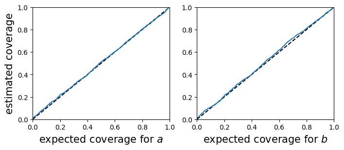

```python
fig = plt.figure(figsize=(8,3))
sub = fig.add_subplot(121)
sub.plot([0., 1.], [0., 1.], c='k', ls='--')
sub.plot(np.linspace(0., 1., 100), cdf_a)
sub.set_xlabel('expected coverage for $a$', fontsize=15)
sub.set_ylabel('estimated coverage', fontsize=15)
sub.set_xlim(0, 1.); sub.set_ylim(0., 1.)

sub = fig.add_subplot(122)
sub.plot([0., 1.], [0., 1.], c='k', ls='--')
sub.plot(np.linspace(0., 1., 100), cdf_b)
sub.set_xlabel('expected coverage for $b$', fontsize=15)
sub.set_xlim(0, 1.); sub.set_ylim(0., 1.); plt.show()
```

# Tests of Accuracy with Random Points (TARP) coverage

The validation above were for the 1D marginal posteriors for $a$ and $b$ separately. Now lets try TARP using their python package: [`tarp`](https://github.com/Ciela-Institute/tarp)

```python
import tarp
```

```python
q_samp = []
for _theta, _data in zip(theta_test, data_test):
    _q_samples = npe_maf.sample((1000,), x=torch.tensor(_data, dtype=torch.float32), show_progress_bars=False)
    q_samp.append(_q_samples)
q_samp = np.array(q_samp)
```

```python
ecp, alpha = tarp.get_tarp_coverage(q_samp, theta_test,
                                    references="random",
                                    metric="euclidean")
```

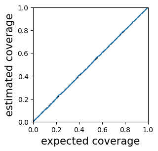

```python
fig = plt.figure(figsize=(3,3))
sub = fig.add_subplot(111)
sub.plot([0., 1.], [0., 1.], c='k', ls='--')
sub.plot(alpha, ecp)
sub.set_xlabel('expected coverage', fontsize=15)
sub.set_ylabel('estimated coverage', fontsize=15)
sub.set_xlim(0, 1.); sub.set_ylim(0., 1.); plt.show()
```

This confirms that the MAF provides a well-calibrated posterior!

# unit summary